# 01 — K562 Perturb-seq import and QC

# Data and conversion

The source is the public Replogle et al. K562 essential-gene CRISPRi H5AD (`10.25452/figshare.plus.20029387`). Its legacy AnnData encoding is converted without changing the raw file. From the project root, run `python scripts/prepare_k562_subset.py` to calculate full-dataset QC and write a sparse, modern H5AD. The seeded analysis sample retains at least five cells per perturbation when available, then samples the remaining cells at random to 12,000 cells.

```r
library(anndataR)
library(Seurat)
library(Matrix)
library(ggplot2)
library(dplyr)
```

```r
path <- "data/processed/01_k562_analysis.h5ad"
stopifnot(file.exists(path))
adata <- read_h5ad(path)
cat("Analysis dimensions (cells x genes):", paste(dim(adata), collapse=" x "), "\n")
```

```
Analysis dimensions (cells x genes): 12000 x 8563
```

```r
cat("obs columns:", paste(colnames(adata$obs), collapse=", "), "\n")
```

```
obs columns: gem_group, gene, gene_id, transcript, gene_transcript, sgID_AB, mitopercent, UMI_count, z_gemgroup_UMI, core_scale_factor, core_adjusted_UMI_count, nCount_RNA, nFeature_RNA, percent.mt
```

```r
cat("var columns:", paste(colnames(adata$var), collapse=", "), "\n")
```

```
var columns: gene_name, chr, start, end, class, strand, length, in_matrix, mean, std, cv, fano, ensembl_id
```

```r
stopifnot("gene" %in% colnames(adata$obs))
```

```r
counts <- t(adata$X)
stopifnot(inherits(counts, "sparseMatrix"))
rownames(counts) <- rownames(adata$var)
colnames(counts) <- rownames(adata$obs)
meta <- as.data.frame(adata$obs)
rownames(meta) <- colnames(counts)
obj <- CreateSeuratObject(counts=counts, meta.data=meta, project="Replogle_K562_CRISPRi")
cat("Sparse matrix:", class(counts)[1], "nonzero entries:", length(counts@x), "\n")
```

```
Sparse matrix: dgRMatrix nonzero entries: 43595946
```

```r
summary(obj$nCount_RNA)
```

```
   Min. 1st Qu.  Median    Mean 3rd Qu.    Max.
   3432   10561   13302   13969   16825   33681
```

```r
summary(obj$nFeature_RNA)
```

```
   Min. 1st Qu.  Median    Mean 3rd Qu.    Max.
   1514    3184    3626    3633    4113    5520
```

### Interpretation

The source contains 310,385 cells and 8,563 genes. Count and detected-feature summaries are derived from the sparse expression matrix, which retains zero values without a dense allocation. These measures provide the basis for the recorded QC limits.

# QC and perturbation coverage

```r
qc <- read.csv("results/01_qc_report.csv")
qc
```

| before | after | analysis | feature_lower | feature_upper | count_lower | count_upper | mt_gene_count | mt_max_percent | seed | guaranteed_per_target |
| --- | --- | --- | --- | --- | --- | --- | --- | --- | --- | --- |
| 310385 | 305906 | 12000 | 1506 | 5538 | 3431 | 33694 | 13 | 20 | 42 | 5 |

```r
cat("Mitochondrial genes:", qc$mt_gene_count, "\n")
```

```
Mitochondrial genes: 13
```

```r
if (qc$mt_gene_count > 0) print(summary(obj$percent.mt))
```

```
   Min. 1st Qu.  Median    Mean 3rd Qu.    Max.
 0.2179  9.1956 10.7660 10.8400 12.4474 19.9859
```

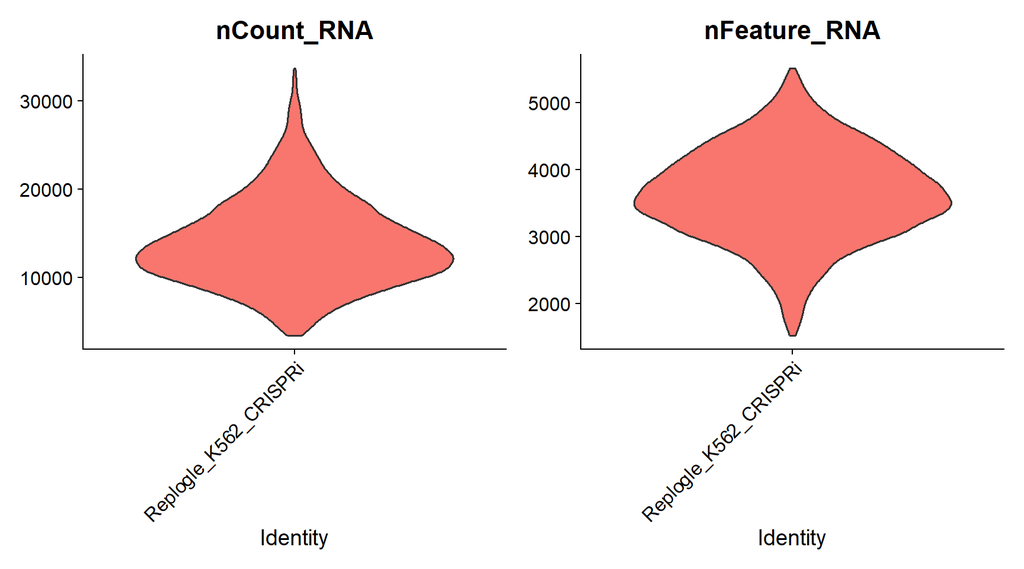

```r
VlnPlot(obj, features=c("nCount_RNA", "nFeature_RNA"), pt.size=0)
```

### Interpretation

QC retained 305,906 of 310,385 cells (98.6%), indicating modest rather than aggressive removal. Count and feature limits use the full-dataset 0.5% and 99.5% quantiles; 13 observed mitochondrial genes support the 20% mitochondrial ceiling. The violin plots describe the retained sample’s QC distributions and do not independently establish biological quality.

```r
full_counts <- read.csv("results/01_perturbation_cell_counts.csv")
sample_counts <- read.csv("results/01_analysis_perturbation_counts.csv")
cat("Perturbations after QC:", nrow(full_counts), "\n")
```

```
Perturbations after QC: 2058
```

```r
cat("Perturbations in analysis:", nrow(sample_counts), "\n")
```

```
Perturbations in analysis: 2058
```

```r
summary(sample_counts$n_cells)
```

```
   Min. 1st Qu.  Median    Mean 3rd Qu.    Max.
  5.000   5.000   5.000   5.831   6.000  76.000
```

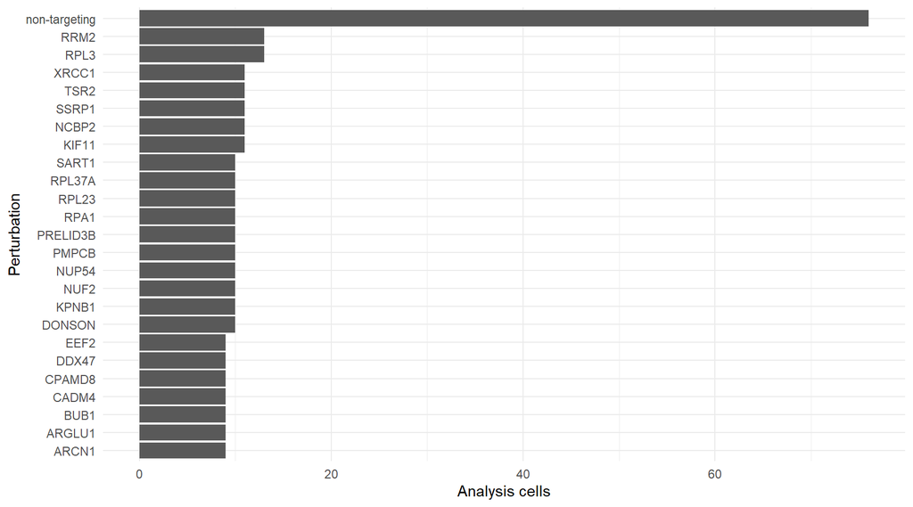

```r
ggplot(head(sample_counts, 25), aes(x=reorder(gene, n_cells), y=n_cells)) +
  geom_col() + coord_flip() + labs(x="Perturbation", y="Analysis cells") + theme_minimal()
```

### Interpretation

The seeded 12,000-cell subset retains all 2,058 post-QC perturbation labels, making it useful for broad coverage and global structure. Its median is five cells per label; the frequency plot highlights uneven representation, including 76 non-targeting cells. This subset is too sparse for reliable detailed differential expression across all targets.

```r
saveRDS(obj, "data/processed/01_k562_qc_seurat.rds")
```

## Key results

```r
cat("Full cells:", qc$before, "after QC:", qc$after, "analysis cells:", qc$analysis, "\n")
```

```
Full cells: 310385 after QC: 305906 analysis cells: 12000
```

```r
cat("Genes:", nrow(obj), "perturbations:", nrow(sample_counts), "\n")
```

```
Genes: 8563 perturbations: 2058
```

- **Source data:** 310,385 cells × 8,563 genes provide the full public input.
- **QC-filtered data:** 305,906 cells (98.6%) remain after the recorded count, feature, and mitochondrial limits.
- **Broad coverage subset:** 12,000 seeded cells retain all 2,058 labels for global analysis, with limited per-target power.